# Statistical Inference Course Project

#### Overview

This project is spilt into 2 parts. They will be spilt into simulation and statistical analysis of tooth growth data. For the simulation part, we will investigate the exponential distribution in R and compare it with the Central Limit Theorem. For the statistical analysis, we will see if there are significant differences in the means of using OJ or VC in the tooth growth dataset.

### Part 1: Simulation

##### A. Mean

Simulated mean is the barchart - in this case is 5 -5.2, since most of the observations are clustered near 5. Theoretical mean is the black line - in this case is 5, because the theoretical mean is 5

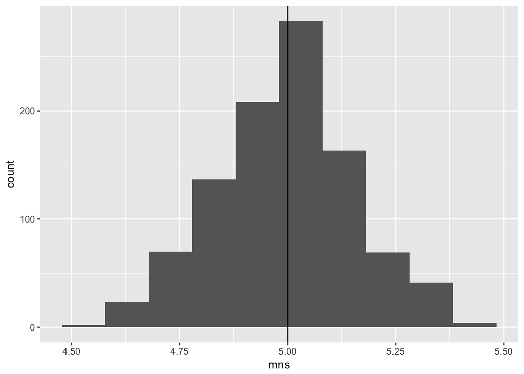

```r
mns = NULL
for (i in 1 : 1000) mns = c(mns, mean(rexp(1000, 0.2)))
ggplot() +geom_histogram(aes(mns), bins = 10, fill ="grey40") +
        geom_vline( xintercept = 5)
```

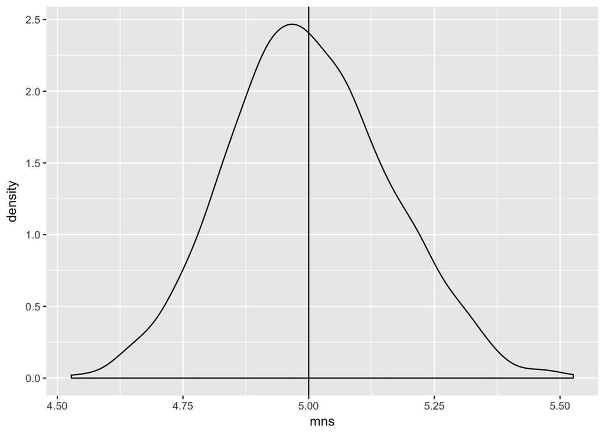

```r
mns = NULL
for (i in 1 : 1000) mns = c(mns, mean(rexp(1000, 0.2)))
ggplot() +geom_density(aes(mns))+
        geom_vline( xintercept = 5)
```

From the density and histogram, we can see that it is approx normal, since they concentrate near the mean, and is approximately symmetrical about the mean.

### Part 2: Statistical Analysis of Tooth growth data

```r
datadf <- ToothGrowth
```

Generally, Orange Juice tend to be more effective for the tooth growth as compared to VC, as the length tends to be higher.

```r
summary(datadf)
```

```
##       len        supp         dose
##  Min.   : 4.20   OJ:30   Min.   :0.500
##  1st Qu.:13.07   VC:30   1st Qu.:0.500
##  Median :19.25           Median :1.000
##  Mean   :18.81           Mean   :1.167
##  3rd Qu.:25.27           3rd Qu.:2.000
##  Max.   :33.90           Max.   :2.000
```

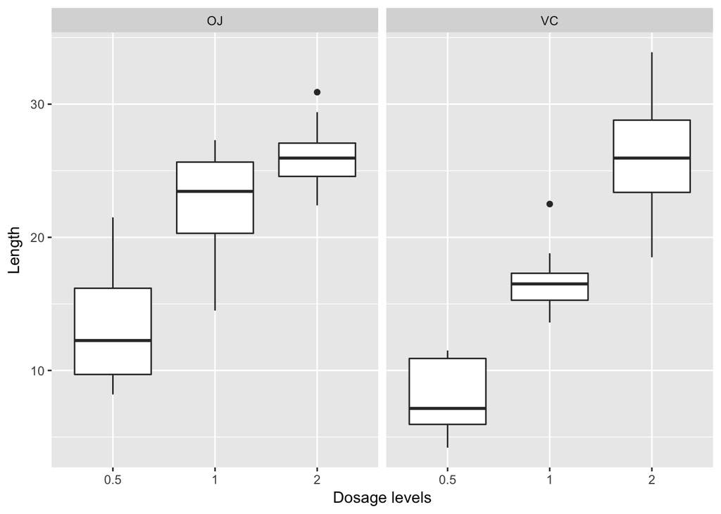

```r
ggplot(datadf) +
  geom_boxplot(aes(x = factor(dose), y = len ))+
  facet_grid(~supp) +
  xlab("Dosage levels") + ylab("Length")
```

We conduct T - test to see if the difference in mean is significant:  
H0: mean of OJ will be equal to the mean of VC  
Ha: mean of OJ will not be equal to mean of VC

```r
OJdata <- subset(datadf, supp =="OJ")
VCdata <- subset(datadf, supp =="VC")
t.test(OJdata$len, VCdata$len,var.equal = FALSE, paired =FALSE )
```

```
##
##  Welch Two Sample t-test
##
## data:  OJdata$len and VCdata$len
## t = 1.9153, df = 55.309, p-value = 0.06063
## alternative hypothesis: true difference in means is not equal to 0
## 95 percent confidence interval:
##  -0.1710156  7.5710156
## sample estimates:
## mean of x mean of y
##  20.66333  16.96333
```

Since p is not significant, we do not reject the null hypothesis and the mean is not significant, at the 95th CI.